# Lab4

Author

Danial Shaikh

```r
library(tidyverse)
library(dplyr)
library(here)
```

```r
# Code for question 2.0
avocado <- read_csv(here("Week4","avocado.csv"))
```

[output not shown]

```r
avocado
```

```
# A tibble: 18,249 × 14
    ...1 Date       Avera…¹ Total…² `4046` `4225` `4770` Total…³ Small…⁴ Large…⁵
   <dbl> <date>       <dbl>   <dbl>  <dbl>  <dbl>  <dbl>   <dbl>   <dbl>   <dbl>
 1     0 2015-12-27    1.33  64237.  1037. 5.45e4   48.2   8697.   8604.    93.2
 2     1 2015-12-20    1.35  54877.   674. 4.46e4   58.3   9506.   9408.    97.5
 3     2 2015-12-13    0.93 118220.   795. 1.09e5  130.    8145.   8042.   103.
 4     3 2015-12-06    1.08  78992.  1132  7.20e4   72.6   5811.   5677.   134.
 5     4 2015-11-29    1.28  51040.   941. 4.38e4   75.8   6184.   5986.   198.
 6     5 2015-11-22    1.26  55980.  1184. 4.81e4   43.6   6684.   6556.   127.
 7     6 2015-11-15    0.99  83454.  1369. 7.37e4   93.3   8319.   8197.   122.
 8     7 2015-11-08    0.98 109428.   704. 1.02e5   80     6829.   6267.   562.
 9     8 2015-11-01    1.02  99811.  1022. 8.73e4   85.3  11388.  11105.   284.
10     9 2015-10-25    1.07  74339.   842. 6.48e4  113     8626.   8061.   564.
# … with 18,239 more rows, 4 more variables: `XLarge Bags` <dbl>, type <chr>,
#   year <dbl>, region <chr>, and abbreviated variable names ¹AveragePrice,
#   ²`Total Volume`, ³`Total Bags`, ⁴`Small Bags`, ⁵`Large Bags`
```

Question 2.1

The dataset contains information about avocado prices and sales in the United States from 2015 to 2018. The information includes the following variables:

- Date: the date of the observation
- AveragePrice: average price of a single avocado
- Total Volume: total number of avocados sold
- 4046: total number of avocados with PLU 4046 sold
- 4225: total number of avocados with PLU 4225 sold
- 4770: total number of avocados with PLU 4770 sold
- Total Bags: total number of bags of avocados sold
- Small Bags: total number of small bags of avocados sold
- Large Bags: total number of large bags of avocados sold
- XLarge Bags: total number of extra large bags of avocados sold
- type: conventional or organic
- year: year of the observation
- region: geographical region in the US where the observation was made.

```r
avocado_clean <- avocado
length(unique(avocado_clean$region))
```

```
[1] 54
```

```r
avocado_clean |>
  rename(
    Small = `4046`, Large = `4225`,xtraLarge = `4770`)
```

```
# A tibble: 18,249 × 14
    ...1 Date       Avera…¹ Total…² Small  Large xtraL…³ Total…⁴ Small…⁵ Large…⁶
   <dbl> <date>       <dbl>   <dbl> <dbl>  <dbl>   <dbl>   <dbl>   <dbl>   <dbl>
 1     0 2015-12-27    1.33  64237. 1037. 5.45e4    48.2   8697.   8604.    93.2
 2     1 2015-12-20    1.35  54877.  674. 4.46e4    58.3   9506.   9408.    97.5
 3     2 2015-12-13    0.93 118220.  795. 1.09e5   130.    8145.   8042.   103.
 4     3 2015-12-06    1.08  78992. 1132  7.20e4    72.6   5811.   5677.   134.
 5     4 2015-11-29    1.28  51040.  941. 4.38e4    75.8   6184.   5986.   198.
 6     5 2015-11-22    1.26  55980. 1184. 4.81e4    43.6   6684.   6556.   127.
 7     6 2015-11-15    0.99  83454. 1369. 7.37e4    93.3   8319.   8197.   122.
 8     7 2015-11-08    0.98 109428.  704. 1.02e5    80     6829.   6267.   562.
 9     8 2015-11-01    1.02  99811. 1022. 8.73e4    85.3  11388.  11105.   284.
10     9 2015-10-25    1.07  74339.  842. 6.48e4   113     8626.   8061.   564.
# … with 18,239 more rows, 4 more variables: `XLarge Bags` <dbl>, type <chr>,
#   year <dbl>, region <chr>, and abbreviated variable names ¹AveragePrice,
#   ²`Total Volume`, ³xtraLarge, ⁴`Total Bags`, ⁵`Small Bags`, ⁶`Large Bags`
```

```r
major_regions <- c("Plains", "Midsouth", "West", "SouthCentral", "Northeast", "Southeast")

major_regions <- avocado_clean |>
  filter(region %in% major_regions) |>
  rename(
    Small = `4046`, Large = `4225`,xtraLarge = `4770`)


metro_regions <- avocado_clean |>
  filter(!(region %in% c(major_regions, "TotalUS")))|>
  rename(
    Small = `4046`, Large = `4225`,xtraLarge = `4770`)

major_regions
```

```
# A tibble: 2,028 × 14
    ...1 Date       AveragePrice Total V…¹  Small  Large xtraL…² Total…³ Small…⁴
   <dbl> <date>            <dbl>     <dbl>  <dbl>  <dbl>   <dbl>   <dbl>   <dbl>
 1     0 2015-12-27         1.05  2065131. 4.35e5 1.02e6 103812. 503211. 464119.
 2     1 2015-12-20         1.05  2044021. 4.46e5 1.02e6  96387. 476795. 434534.
 3     2 2015-12-13         1.03  2193143. 5.15e5 1.06e6 113979. 503346. 445275.
 4     3 2015-12-06         1     2233138. 5.07e5 1.15e6 133317. 437811. 377999.
 5     4 2015-11-29         1.05  1845443. 4.18e5 9.39e5 101740. 386816. 344831.
 6     5 2015-11-22         1.06  1903245  4.22e5 9.56e5 117353. 407482. 364156.
 7     6 2015-11-15         1.02  2355839. 4.70e5 1.30e6 168587. 414550. 373075.
 8     7 2015-11-08         1.04  2503008. 5.69e5 1.25e6 228267. 457858. 402489.
 9     8 2015-11-01         1.08  2511760. 5.49e5 1.19e6 260946. 513482. 429082.
10     9 2015-10-25         1.13  2188485. 5.22e5 9.81e5 211478. 474081. 417038.
# … with 2,018 more rows, 5 more variables: `Large Bags` <dbl>,
#   `XLarge Bags` <dbl>, type <chr>, year <dbl>, region <chr>, and abbreviated
#   variable names ¹`Total Volume`, ²xtraLarge, ³`Total Bags`, ⁴`Small Bags`
```

**3.** Which major region sold the most organic, small Hass avocados in 2017?

```r
major_regions |>
  filter(type == "organic", year == 2017) |>
  group_by(region) |>
  summarize(tot_small_bags = sum(Small)) |>
  arrange(desc(tot_small_bags)) |>
  slice(1)
```

```
# A tibble: 1 × 2
  region tot_small_bags
  <chr>           <dbl>
1 West         1870206.
```

**4.** Use the `separate()` function to split the `Date` variable into year, month, and day. In which month is the highest volume of avocado sales?

```r
avocado_clean |>
  separate(Date, into = c("Year", "Month", "Day"), sep = "-") |>
  group_by(Month) |>
  summarize(tot_sales = sum(`Total Volume`)) |>
  arrange(desc(tot_sales)) |>
  slice(1)
```

```
# A tibble: 1 × 2
  Month   tot_sales
  <chr>       <dbl>
1 02    1760528797.
```

```r
mostAvo5 <- metro_regions |>
    group_by(region) |>
    summarise(average_total_volume = mean(`Total Volume`)) |>
    arrange(desc(average_total_volume)) |>
    head(5) |>
    pull(region)

ggplot(data = avocado_clean |> filter(region %in% top5regions),
       aes(x = region, y = `Total Volume`, fill = region)) +
  geom_boxplot()
```

[output not shown]

[output not shown]

```
Error in `filter()`:
! Problem while computing `..1 = region %in% top5regions`.
Caused by error in `region %in% top5regions`:
! object 'top5regions' not found
```

**6.** In which regions is the price of organic versus conventional avocados most different? Support your answer with a few summary statistics and a visualization.

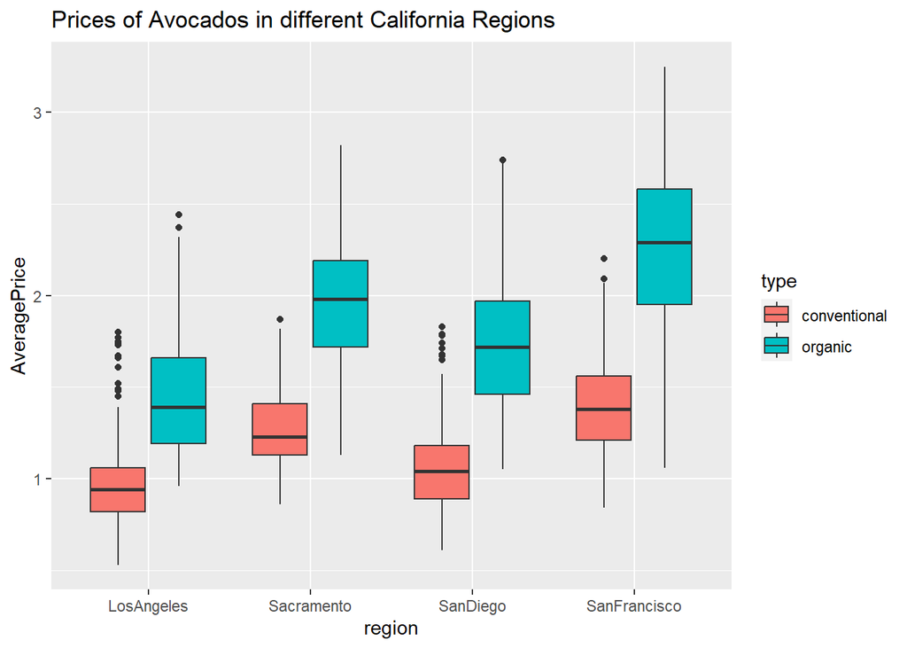

```r
cali <- avocado_clean |>
  filter(region %in% c("LosAngeles", "SanDiego", "Sacramento", "SanFrancisco"))

ggplot(data = cali, aes(x = region, y = AveragePrice, fill = type)) +
  geom_boxplot() +
  ggtitle("Prices of Avocados in different California Regions")
```

```r
cali |>
  group_by(region, type) |>
  summarise(average_price = mean(AveragePrice)) |>
  pivot_wider(names_from = type, values_from = average_price, values_fill = 0) |>
  mutate(
    price_difference = organic - conventional
  )
```

```
# A tibble: 4 × 4
# Groups:   region [4]
  region       conventional organic price_difference
  <chr>               <dbl>   <dbl>            <dbl>
1 LosAngeles          0.976    1.46            0.479
2 Sacramento          1.27     1.97            0.695
3 SanDiego            1.06     1.73            0.673
4 SanFrancisco        1.40     2.21            0.814
```

```r
cali
```

```
# A tibble: 1,352 × 14
    ...1 Date       Avera…¹ Total…² `4046` `4225` `4770` Total…³ Small…⁴ Large…⁵
   <dbl> <date>       <dbl>   <dbl>  <dbl>  <dbl>  <dbl>   <dbl>   <dbl>   <dbl>
 1     0 2015-12-27    0.8   2.33e6 9.77e5 4.55e5 86202.  8.09e5 722788.  74359.
 2     1 2015-12-20    0.85  2.15e6 8.71e5 3.97e5 96112.  7.87e5 681332.  94922.
 3     2 2015-12-13    0.74  2.69e6 1.07e6 4.56e5 67975.  1.09e6 962785. 123270.
 4     3 2015-12-06    0.66  3.05e6 1.20e6 6.83e5 64728.  1.10e6 997846.  92325.
 5     4 2015-11-29    0.83  2.16e6 8.33e5 5.02e5 70944.  7.50e5 681435.  61343.
 6     5 2015-11-22    0.81  2.27e6 8.86e5 5.58e5 75963.  7.48e5 676326.  64490.
 7     6 2015-11-15    0.74  2.83e6 1.28e6 6.62e5 70734.  8.14e5 763323.  44152.
 8     7 2015-11-08    0.84  2.62e6 1.31e6 7.03e5 75385.  5.28e5 492714.  29335.
 9     8 2015-11-01    0.89  2.62e6 1.23e6 9.15e5 74253.  3.96e5 378049.  13372.
10     9 2015-10-25    0.95  2.33e6 9.74e5 9.25e5 78774.  3.49e5 341731.   3775.
# … with 1,342 more rows, 4 more variables: `XLarge Bags` <dbl>, type <chr>,
#   year <dbl>, region <chr>, and abbreviated variable names ¹AveragePrice,
#   ²`Total Volume`, ³`Total Bags`, ⁴`Small Bags`, ⁵`Large Bags`
```

```r
cali_grouped <- group_by(cali_avo, region, type)
```

[output not shown]

```r
cali_summarized <- summarize_at(cali_grouped, vars(Size_Small, Size_Large, Size_XL), funs(mean))
```

[output not shown]

```r
cali_gathered <- gather(cali_summarized, key = "Size", value = "Num.Sold", -region, -type)
```

[output not shown]

```r
cali_mutated <- mutate(cali_gathered,
                       Size = factor(Size,
                                     levels = c("Size_Small", "Size_Large", "Size_XL"),
                                     labels = c("Small", "Large", "Extra Large"))
                      )
```

[output not shown]

```r
cali_plotted <- ggplot(cali_mutated, aes(x = region, y = Num.Sold, fill = Size)) +
                geom_col(position = "fill") +
                facet_wrap(~type)
```

[output not shown]

```
Error in ggplot(cali_mutated, aes(x = region, y = Num.Sold, fill = Size)): object 'cali_mutated' not found
```

```r
cali_plotted
```

[output not shown]

```
Error in eval(expr, envir, enclos): object 'cali_plotted' not found
```